# Лабораторная работа №5

Основы информационной безопасности

Верниковская Е. А., НПИбд-01-23

Российский университет дружбы народов, Москва, Россия

17 апреля 2025

# Вводная часть

## Цель работы

Целью данной работы является изучение механизмов изменения идентификаторов, применения SetUID- и Sticky-битов. Получение практических навыков работы в консоли с дополнительными атрибутами. Рассмотрение работы механизма смены идентификатора процессов пользователей, а также влияние бита Sticky на запись и удаление файлов.

# Выполнение лабораторной работы

## Подготовка лабораторного стенда

Для лабораторной работы необходимо проверить, установлен ли компилятор gcc. Проверим это с помощью команды *gcc -v*. Также осуществим отключение системы запретов с помощью *sudo setenforce 0* и проверим командой *getenforce*, что выводится Permissive (рис. 1)

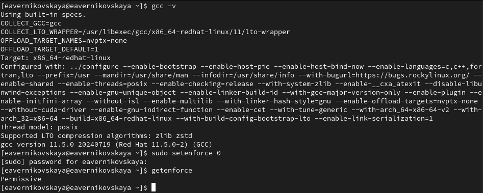

Подготовка к лабораторной работе

## Создание программы

Войдём в систему от имени пользователя guest. И создадим программу simpleid.c (рис. 2), (рис. 3)

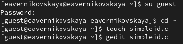

Создание и открытие файла simpleid.c

## Создание программы

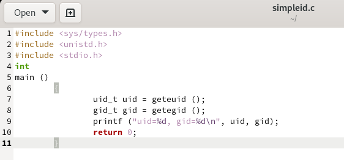

Редактирование файла simpleid.c

## Создание программы

Скомплилируем программу и убедимся, что файл программы создан: *gcc simpleid.c -o simpleid* (рис. 4)

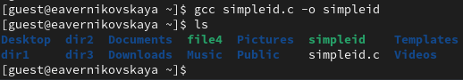

Компиляция программы simpleid.c

## Создание программы

Выполним программу simpleid: *./simpleid*. В выводе файла выписыны номера пользоватея и групп, от вывода при вводе id, они отличаются только тем, что информации меньше (рис. 5)

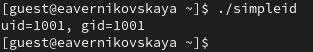

Выполнение программы simpleid

## Создание программы

Выполните системную программу id: *id* (рис. 6)

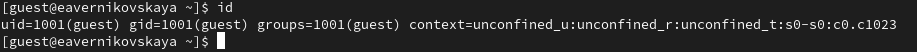

Выполнение системной программы id

## Создание программы

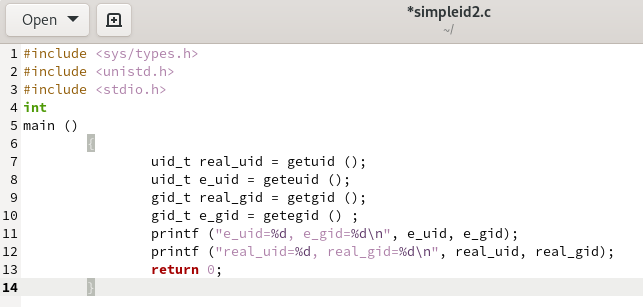

Редактирование файла simpleid2.c

## Создание программы

Скомпилируем и запустим simpleid2.c: *gcc simpleid2.c -o simpleid2* и *./simpleid2* (рис. 9), (рис. 10)

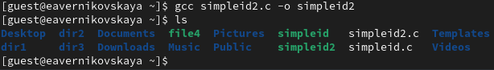

Компиляция программы simpleid2.c

## Создание программы

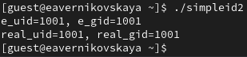

Выполнение программы simpleid2

## Создание программы

От имени суперпользователя выполним команды: *chown root:guest /home/guest/simpleid2* и *chmod u+s /home/guest/simpleid2*. Также выполним проверку правильности установки новых атрибутов и смены владельца файла simpleid2: *ls -l simpleid2*. С помощью chown мы меняем владельца файла на суперпользователя, а с помощью chmod меняем права доступа (рис. 11)

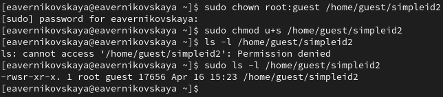

Смена владельца файла и прав доступа к файлу simpleid2

## Создание программы

Запустим simpleid2 и id: *./simpleid2* и *id*. Наша команда снова вывела только ограниченное количество информации (рис. 12)

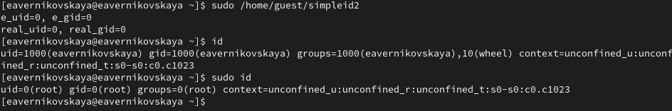

Запуск simpleid2 и id

## Создание программы

Создадим программу readfile.c (рис. 13), (рис. 14)

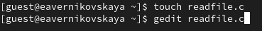

Создание и открытие файла readfile.c

## Создание программы

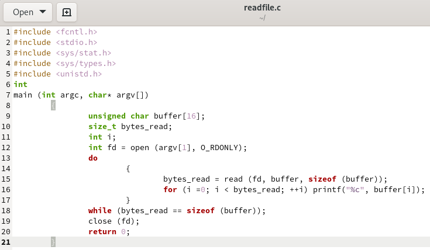

Редактирование файла readfile.c

## Создание программы

Откомпилируем её: *gcc readfile.c -o readfile* (рис. 15)

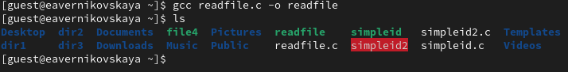

Компиляция программы readfile.c

## Создание программы

Далее сменим владельца у файла readfile.c и изменим права так, чтобы только суперпользователь (root) мог прочитать его, a guest не мог (рис. 16)

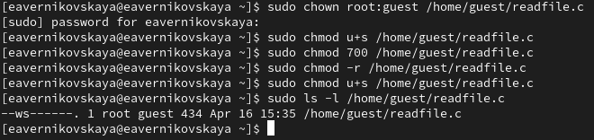

Смена владельца файла и прав доступа к файлу readfile

## Создание программы

Проверим, что пользователь guest не может прочитать файл readfile.c (рис. 17)

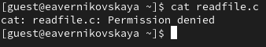

Попытка прочесть содержимое файла readfile.c

## Создание программы

Проверим, может ли программа readfile прочитать файл readfile.c (рис. 18)

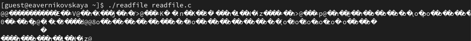

Попытка прочесть содержимое файла readfile.c программой readfile

## Создание программы

Проверим, может ли программа readfile прочитать файл /etc/shadow (рис. 19)

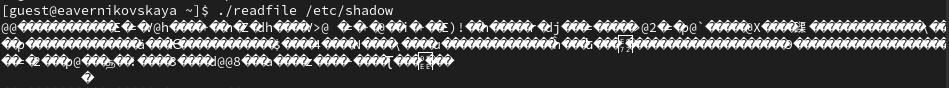

Попытка прочесть содержимое файла /etc/shadow программой readfile

## Создание программы

Теперь попробуем прочесть эти же файлы от имени суперпользователя (рис. 20)

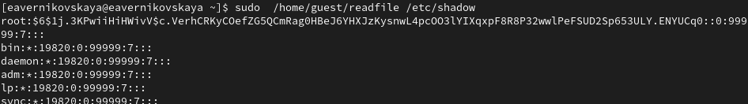

Попытка прочесть содержимое файлов от имени суперпользователя

## Исследование Sticky-бита

Выясним, установлен ли атрибут Sticky на директории /tmp, для чего выполним команду *ls -l / | grep tmp*. Так как ввыводе есть буква t, это значит что атрибут установлен (рис. 21)

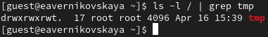

Проверка атрибутов директории tmp

## Исследование Sticky-бита

От имени пользователя guest создадим файл file01.txt в директории /tmp со словом test: *echo “test” > /tmp/file01.txt* (рис. 22)

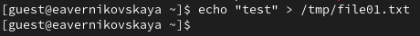

Создание файла file01.txt со словом test

## Исследование Sticky-бита

Просмотрим атрибуты у только что созданного файла *ls -l /tmp/file01.txt* и разрешим чтение и запись для категории пользователей «все остальные»: *chmod o+rw /tmp/file01.txt* (рис. 23)

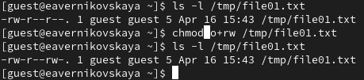

Смена атрибутов файла file01.txt

## Исследование Sticky-бита

От пользователя guest2 (не являющегося владельцем) попробуем прочитать файл /tmp/file01.txt: *cat /tmp/file01.txt* (рис. 24)

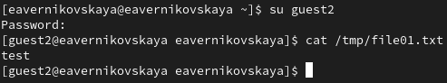

Попытка чтеня файла

## Исследование Sticky-бита

От пользователя guest2 попробуем дозаписать в файл /tmp/file01.txt слово test2 командой *echo “test2” > /tmp/file01.txt* (рис. 25)

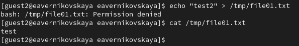

Попытка дозаписи в файл

## Исследование Sticky-бита

От пользователя guest2 попробуем записать в файл /tmp/file01.txt слово test3, стерев при этом всю имеющуюся в файле информацию командой *echo “test3” > /tmp/file01.txt* (рис. 26)

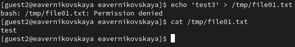

Попытка записи в файл и удаление всей имеющейся в нём информации

## Исследование Sticky-бита

От пользователя guest2 попробуем удалить файл /tmp/file01.txt командой *rm /tmp/file01.txt* (рис. 27)

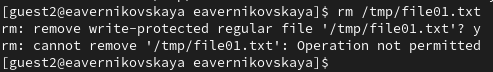

Попытка удалить файл

## Исследование Sticky-бита

Далее от имени суперпользователя снимем с директории tmp атрибут Sticky командой *chmod -t /tmp* (рис. 28), (рис. 29)

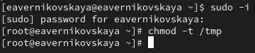

Снятие с директории tmp атрибута Sticky

## Исследование Sticky-бита

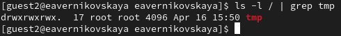

Проверка того что атрибут снялся

## Исследование Sticky-бита

Далее снова проделаем предыдущие шаги. Всё то же самое только теперь можно удалить файл (рис. 30)

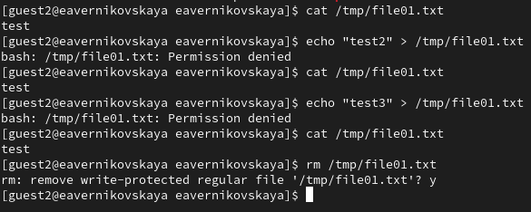

Повтор предыдущих действий после снятия атрибута Sticky

## Исследование Sticky-бита

Вернём директории tmp атрибут t от имени суперпользователя (рис. 31)

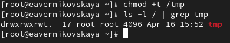

Изменение атрибутов

# Подведение итогов

## Выводы

В результате выполнения работы мы изучили механизмы изменения идентификаторов, применения SetUID- и Sticky-битов. Получили практические навыки работы в консоли с дополнительными атрибутами. Рассмотрели работы механизма смены идентификатора процессов пользователей, а также влияние бита Sticky на запись и удаление файлов

## Список литературы

1. Лаборатораня работа №5 [Электронный ресурс] URL: https://esystem.rudn.ru/pluginfile.php/2580984/mod_resource/content/2/005-lab_discret_sticky.pdf
2. Инструментарий программиста в Linux: Компилятор GCC [Электронный ресурс] URL: http://parallel.imm.uran.ru/freesoft/make/instrum.html